# Eating Out

CarmelVilla

2023-07-19

# 1 Introduction

Does the number of times that people of different ethnicities eat out differ?

## 1.1 There were two years in which the General Social Survey asked about the frequency of eating out.

### 1.1.1 Find those years and for the first year the question was asked download that years data in a stata format - its name will be “GSSxxxx.dta” where the xxxx is replaced by the year. For example if the year was 1983 its name would be GSS1983.dta. Your assignment is to download the GSS yearly dataset for the first year the question was asked and then write up the answer to the question by editing the code block in line 31 to eval=TRUE and finish the job.

$H_0$ There is no difference among the various races with frequency of eating out  
$H_A$ There is a statistical difference between at least two races with the frequency of eating out

```r
GSS <-readstata13::read.dta13(file="GSS1996.dta")
```

[output not shown]

[output cut: 137 more lines]

[output not shown]

```r
GSS <- droplevels(GSS)
mydata <- select(GSS,race,age,eatout)
mydata <- na.omit(mydata)
```

# 2 Method

data was retrived from gss.datadowload

# 3 Results

The results show the difference in ethnicities eating out.

## 3.1 graphical results

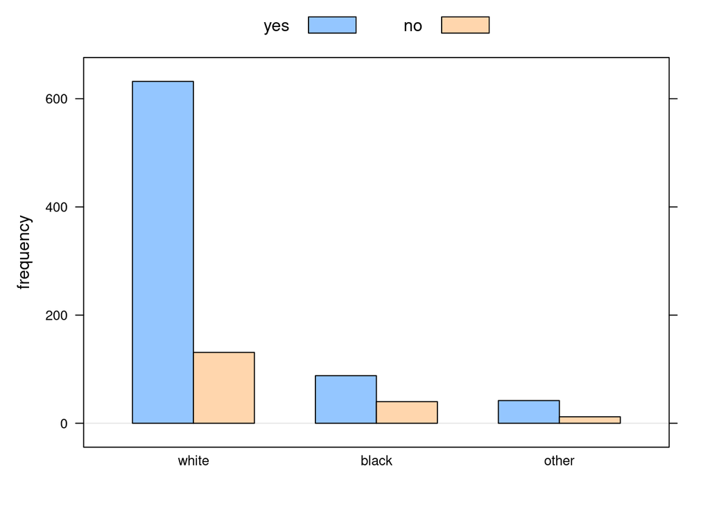

```r
barchartGC(~race + eatout,data=mydata)
```

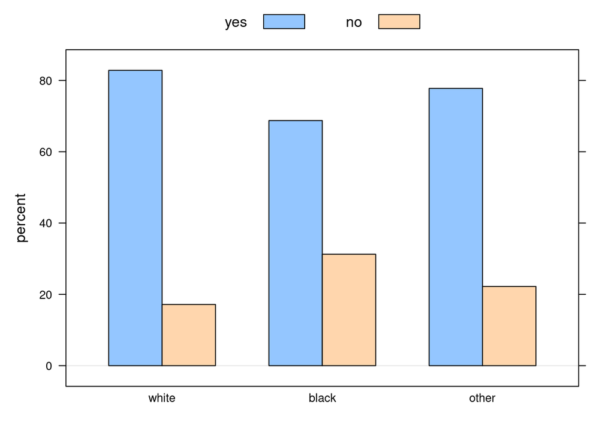

```r
barchartGC(~race + eatout,data=mydata,
type="percent")
```

These graphs shows there is a small difference in certain ethnicities eating out.

## 3.2 Numerical description

```r
table1 <- xtabs(~race + eatout,data=mydata)
rowPerc(table1)
```

```
##        eatout
## race       yes     no  Total
##   white  82.83  17.17 100.00
##   black  68.75  31.25 100.00
##   other  77.78  22.22 100.00
```

```r
colPerc(table1)
```

```
##        eatout
## race       yes     no
##   white  82.94  71.58
##   black  11.55  21.86
##   other   5.51   6.56
##   Total 100.00 100.00
```

It appears that white people eat out more frequent than blacks and other ethnicities.

### 3.2.1 inferential results

```r
chisq.test(table1)
```

```
##
##  Pearson's Chi-squared test
##
## data:  table1
## X-squared = 14.217, df = 2, p-value = 0.0008179
```

```r
chisqtestGC(table1)
```

```
## Pearson's Chi-squared test
##
## Observed Counts:
##        eatout
## race    yes  no
##   white 632 131
##   black  88  40
##   other  42  12
##
## Counts Expected by Null:
##        eatout
## race       yes     no
##   white 615.24 147.76
##   black 103.21  24.79
##   other  43.54  10.46
##
## Contributions to the chi-square statistic:
##        eatout
## race     yes   no
##   white 0.46 1.90
##   black 2.24 9.34
##   other 0.05 0.23
##
##
## Chi-Square Statistic = 14.2174
## Degrees of Freedom of the table = 2
## P-Value = 8e-04
```

```r
fisherXY(mydata$race,mydata$eatout,printAll=T)
```

```
##
## contingency table:
##        y
## x       yes  no
##   white 632 131
##   black  88  40
##   other  42  12
##
## ***All 2X2 tests****
##
## [1] "white" "black"
## [1] "yes" "no"
##        y
## x       yes  no
##   white 632 131
##   black  88  40
##
##  Fisher's Exact Test for Count Data
##
## data:  fTempTable
## p-value = 0.0003864
## alternative hypothesis: true odds ratio is not equal to 1
## 95 percent confidence interval:
##  1.401656 3.385694
## sample estimates:
## odds ratio
##   2.190655
##
##
## [1] "white" "other"
## [1] "yes" "no"
##        y
## x       yes  no
##   white 632 131
##   other  42  12
##
##  Fisher's Exact Test for Count Data
##
## data:  fTempTable
## p-value = 0.3543
```

[output cut: 10 more lines]

```
##        y
## x       yes no
##   black  88 40
##   other  42 12
##
##  Fisher's Exact Test for Count Data
##
## data:  fTempTable
## p-value = 0.2815
## alternative hypothesis: true odds ratio is not equal to 1
## 95 percent confidence interval:
##  0.2719542 1.3820233
## sample estimates:
## odds ratio
##  0.6301155
```

# 4 Discussion and Conclusion